# Proyecto Firmografics

Jorge Gómez-Lechón

12/7/2020

## Objectivos e introducción

El objetivo del presente estudio es analizar la economía del sector de la construcción, uno de los más relevantes para España. Se emplearán diversas técnicas de transformación (principalmente en dplyr) y visualización (ggplot2).

En el marco de análisis, se pretende llevar a cabo un “baseline” del sector de la construcción en España. Para esto, distinguimos dos apartados: análisis externo e interno.

-Análisis externo (o benchmarking): pretende comparar España frente al resto de paises Europeos a través de múltiples métricas como la productividad, el valor añadido, el impacto en empleo, etc. El objetivo de este apartado es entender la posición competitiva de España de la manera más granular posible.

-Análisis interno: pretende determinar las fortalezas y debilidades de la cadena de valor de la construcción, analizando granularmente cada agente respecto a distintas medidas de eficiencia y de impacto.

## Implicaciones

La combinación de ambos análisis puede servir de input para el desarrollo de una estrategia nacional del sector o como estudio de mercado para el sector privado para la toma de decisiones de inversión inmobiliaria. En concreto, se espera que el estudio permita:

-Entender la posición competitiva del país en el sector de la construcción -Detectar oportunidades de mejora sectorial -Detectar barreras al desarrollo del sector -Identificar oportunidades de inversión en función del retorno y la dificultad

## Adquisición de datos y preprocesamiento

```r
##Cargamos las librerías necesarias

library(readr)
library(tidyverse)
library(dplyr)
library(rmarkdown)
library(latexpdf)
##Cargamos los datos desde Eurostats
construction <- read_csv("Transf_sbs_na_con_r2_1_Data.csv")
#Primer contacto con la base de datos y su dimensionalidad
dim(construction)
```

```
## [1] 74127     6
```

```r
head(construction)
```

```
## # A tibble: 6 x 6
##    TIME GEO                   NACE_R2    INDIC_SB                    Value X6
##   <dbl> <chr>                 <chr>      <chr>                       <dbl> <chr>
## 1  2015 European Union - 28 ~ Construct~ Enterprises - number       3.41e6 <NA>
## 2  2015 European Union - 28 ~ Construct~ Turnover or gross premium~ 1.65e6 <NA>
## 3  2015 European Union - 28 ~ Construct~ Production value - millio~ 1.65e6 <NA>
## 4  2015 European Union - 28 ~ Construct~ Value added at factor cos~ 5.34e5 <NA>
## 5  2015 European Union - 28 ~ Construct~ Gross operating surplus -~ 1.95e5 <NA>
## 6  2015 European Union - 28 ~ Construct~ Total purchases of goods ~ 1.12e6 <NA>
```

```r
unique(construction$INDIC_SB)
```

```
##  [1] "Enterprises - number"
##  [2] "Turnover or gross premiums written - million euro"
##  [3] "Production value - million euro"
##  [4] "Value added at factor cost - million euro"
##  [5] "Gross operating surplus - million euro"
##  [6] "Total purchases of goods and services - million euro"
##  [7] "Personnel costs - million euro"
##  [8] "Wages and Salaries - million euro"
##  [9] "Social security costs - million euro"
## [10] "Gross investment in tangible goods - million euro"
## [11] "Persons employed - number"
## [12] "Unpaid persons employed - number"
## [13] "Employees - number"
## [14] "Apparent labour productivity (Gross value added per person employed) - thousand euro"
## [15] "Wage adjusted labour productivity (Apparent labour productivity by average personnel costs) - percentage"
```

[output cut: 17 more lines]

```r
#Limpiamos los registros con nombres muy largos, en concreto Alemania
construction2 <- construction %>% mutate(GEO = ifelse(GEO == "Germany (until 1990 former territory of the FRG)", "Germany", GEO))
```

```r
#Datos vienen como "Char", hay que convertir value a numérico
construction$Value = as.numeric(construction$Value)
#Observamos la base de datos
head(construction2)
```

```
## # A tibble: 6 x 6
##    TIME GEO                   NACE_R2    INDIC_SB                    Value X6
##   <dbl> <chr>                 <chr>      <chr>                       <dbl> <chr>
## 1  2015 European Union - 28 ~ Construct~ Enterprises - number       3.41e6 <NA>
## 2  2015 European Union - 28 ~ Construct~ Turnover or gross premium~ 1.65e6 <NA>
## 3  2015 European Union - 28 ~ Construct~ Production value - millio~ 1.65e6 <NA>
## 4  2015 European Union - 28 ~ Construct~ Value added at factor cos~ 5.34e5 <NA>
## 5  2015 European Union - 28 ~ Construct~ Gross operating surplus -~ 1.95e5 <NA>
## 6  2015 European Union - 28 ~ Construct~ Total purchases of goods ~ 1.12e6 <NA>
```

## Análisis externo:

# Resumen ejecutivo del análisis externo:

- España es uno de los paises que generan un mayor impacto absoluto en el PIB de la construcción en Europa
- Sin embargo, cuenta con una de los peores ratios de productividad en el sector
- En los últimos años, no se ha revertido esta situación, ya que el crecimiento de la productividad es inferior al de la Eurozona
- Las empresas del sector construcción presentan un margen de beneficios del 8%, que se situa en la mediana Europea
- Las diferencias entre productividad y margen de beneficio se explican principalmente por la precariedad laboral de los trabajadores del sector, con uno de los salarios más bajos en Europa
- La mayor ventaja competitiva del país es su capacidad para atraer inversión, la cual sigue aumentando año a año respecto a la Eurozona

# Valor añadido de la construcción:

Observamos que España se encuentra entre los paises que más aportan al PIB Europeo por medio del sector de la construcción, tan solo después de Alemania, Francia e Italia.

España generó en 2018 un valor añadido de casi 50,000 millones al PIB Español.

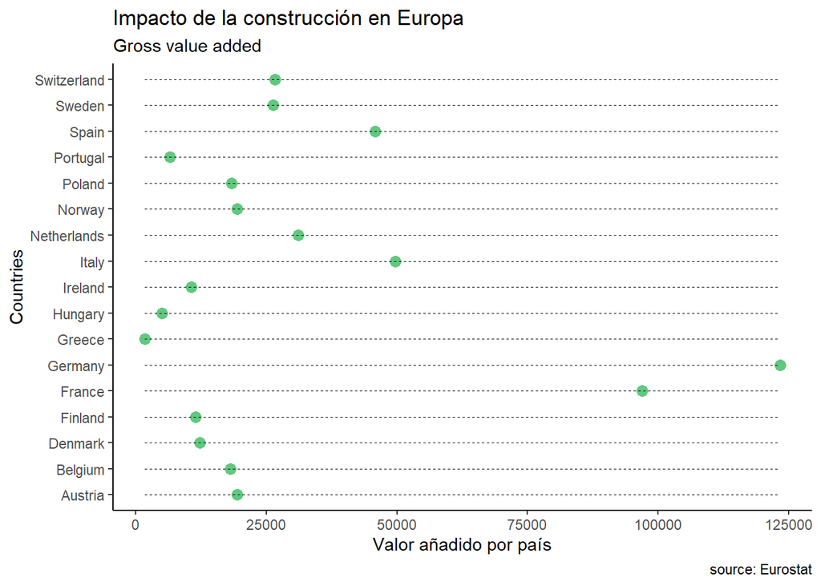

```r
valueadded_pais18 = construction2 %>%
  filter(TIME == 2018) %>%
  filter(NACE_R2 == "Construction" ) %>%
  filter(INDIC_SB == "Value added at factor cost - million euro") %>%
  group_by(GEO)%>%
  arrange(desc(Value))


#Visualización:
library(ggplot2)
library(scales)
theme_set(theme_classic())

# Plot
ggplot(valueadded_pais18, aes(x=valueadded_pais18$GEO, y=valueadded_pais18$Value)) +
  geom_point(col="#61c87f", size=3) +   # Draw points
  geom_segment(aes(x=valueadded_pais18$GEO,
                   xend=valueadded_pais18$GEO,
                   y=min(valueadded_pais18$Value),
                   yend=max(valueadded_pais18$Value)),
               linetype="dashed",
               size=0.1,
               ) +   # Draw dashed lines
  labs(title="Impacto de la construcción en Europa",
       subtitle="Gross value added ",
       caption="source: Eurostat",
       y="Valor añadido por país",
       x="Countries") +
  coord_flip()
```

## Productividad:

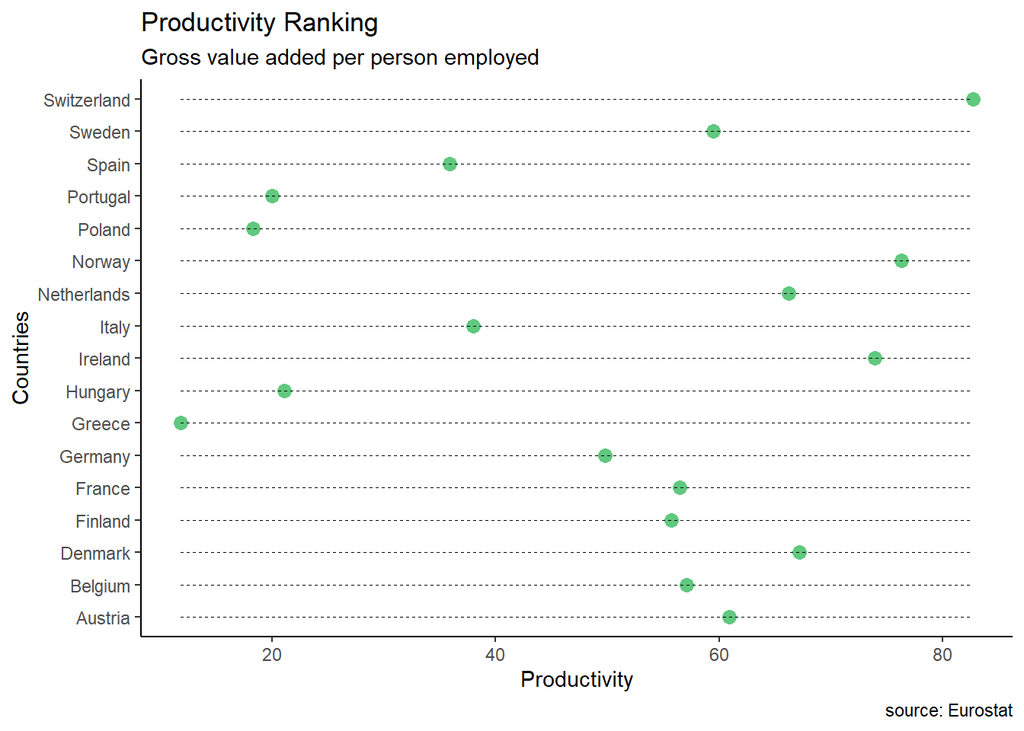

```r
#Ranking de productividad por país en construcción

sp_prodPais_pais18 = construction2 %>%
  filter(TIME == 2018) %>%
  filter(NACE_R2 == "Construction" ) %>%
  filter(INDIC_SB == "Apparent labour productivity (Gross value added per person employed) - thousand euro") %>%
  group_by(GEO)%>%
  arrange(desc(Value))


#Visualización:
library(ggplot2)
library(scales)
theme_set(theme_classic())

# Plot
ggplot(sp_prodPais_pais18, aes(x=sp_prodPais_pais18$GEO, y=sp_prodPais_pais18$Value)) +
  geom_point(col="#61c87f", size=3) +   # Draw points
  geom_segment(aes(x=sp_prodPais_pais18$GEO,
                   xend=sp_prodPais_pais18$GEO,
                   y=min(sp_prodPais_pais18$Value),
                   yend=max(sp_prodPais_pais18$Value)),
               linetype="dashed",
               size=0.1,
               ) +   # Draw dashed lines
  labs(title="Productivity Ranking",
       subtitle="Gross value added per person employed",
       caption="source: Eurostat",
       y="Productivity",
       x="Countries") +
  coord_flip()
```

En otras palabras, España es de los mayores constructores de Europa, pero con una de las peores productividades del sector.

## Rentabilidad

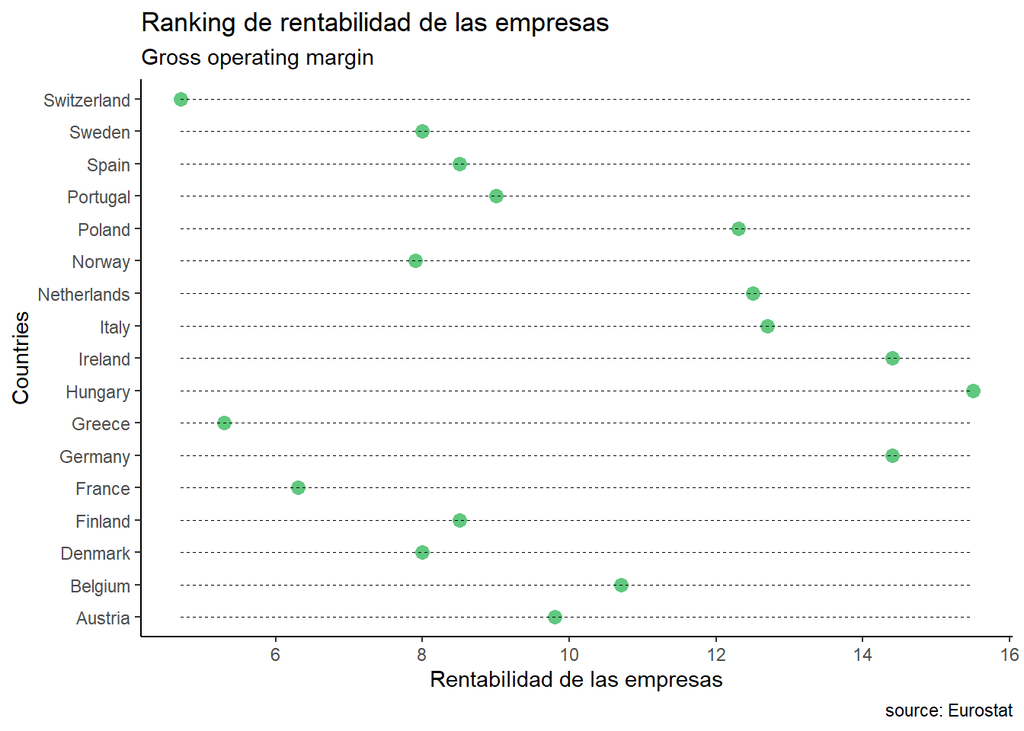

```r
#Ranking de rentabilidad media por empresa por país

grossmargin_pais18 = construction2 %>%
  filter(TIME == 2018) %>%
  filter(NACE_R2 == "Construction" ) %>%
  filter(INDIC_SB == "Gross operating surplus/turnover (gross operating rate) - percentage") %>%
  group_by(GEO)%>%
  arrange(desc(Value))



#Visualización:
library(ggplot2)
library(scales)
theme_set(theme_classic())

# Plot
ggplot(grossmargin_pais18, aes(x=grossmargin_pais18$GEO, y=grossmargin_pais18$Value)) +
  geom_point(col="#61c87f", size=3) +   # Draw points
  geom_segment(aes(x=grossmargin_pais18$GEO,
                   xend=grossmargin_pais18$GEO,
                   y=min(grossmargin_pais18$Value),
                   yend=max(grossmargin_pais18$Value)),
               linetype="dashed",
               size=0.1,
               ) +   # Draw dashed lines
  labs(title="Ranking de rentabilidad de las empresas",
       subtitle="Gross operating margin",
       caption="source: Eurostat",
       y="Rentabilidad de las empresas",
       x="Countries") +
  coord_flip()
```

Se observa que el margen de rentabilidad medio en las empresas de construcción españolas (operativo) es de más de un 8%, que se encuentra aproximadamente en la mediana del sector a nivel Europeo.

Este descubrimiento nos lleva a preguntarnos: ¿cómo es posible que una productividad tan baja resulte en un retorno mediano? Mi hipótesis es que se debe a unas condiciones laborales precarias/ salarios muy bajos en el sector.

Para comprobarlo, compararemos, de nuevo, el salario medio de los trabajadores de la construcción en Europa para validar/invalidar esta hipótesis.

```r
#Ranking de rentabilidad media por empresa por país

#Tabla de salarios
avgwage_pais18 = construction2 %>%
  filter(TIME == 2018) %>%
  filter(NACE_R2 == "Construction" ) %>%
  filter(INDIC_SB == "Wages and Salaries - million euro") %>%
  group_by(GEO)%>%
  arrange(desc(Value))


#Tabla de empleados
num_emp_2018 = construction2 %>%
  filter(TIME == 2018) %>%
  filter(NACE_R2 == "Construction" ) %>%
  filter(INDIC_SB == "Employees - number") %>%
  group_by(GEO)%>%
  arrange(desc(Value))

#Join de las dos tablas
comparacion_salario_emp = inner_join(avgwage_pais18, num_emp_2018, by= "GEO", copy = FALSE)
comparacion_salario_emp = comparacion_salario_emp[, c(2,5,10)]
colnames(comparacion_salario_emp) <- c("GEO", "Total Wages", "Number of Employees")

View(comparacion_salario_emp)

comparacion_salario_emp = comparacion_salario_emp %>%
  mutate((`Total Wages`)*1000000/`Number of Employees`) %>%
  arrange(desc((`Total Wages`)*1000000/`Number of Employees`))

comparacion_salario_emp
```

```
## # A tibble: 16 x 4
## # Groups:   GEO [16]
##    GEO       `Total Wages` `Number of Employ~ `(\`Total Wages\`) * 1e+06/\`Numb~
##    <chr>             <dbl>              <dbl>                              <dbl>
##  1 Ireland           5716.             106047                             53903.
##  2 Denmark           8632.             167508                             51535.
##  3 Norway           12126.             235647                             51459.
##  4 Netherla~        14143.             317545                             44538.
##  5 Austria          11095              286377                             38743.
##  6 Sweden           13658              363845                             37538.
##  7 Finland           6728.             183946                             36578.
##  8 France           53222             1516501                             35095.
##  9 Belgium           7112.             208225                             34154.
## 10 Germany          62527.            2132200                             29325.
## 11 Italy            20398.             787696                             25896.
## 12 Spain            24456.             977050                             25031.
## 13 Portugal          3627.             277670                             13063.
## 14 Poland            6966.             700350                              9947.
## 15 Greece             943.              97729                              9648.
## 16 Hungary           1631.             190054                              8584.
```

Así, validamos como España se encuentra entre los paises con menor renta per capita entre los trabajadores de la construcción. Esto confirma la premisa de que la rentabilidad en la industria de la construcción, queda sostenida por la precariedad laboral.

## Inversión por país

Se continúa analizando la inversión en el sector por país y se observa lo siguiente:

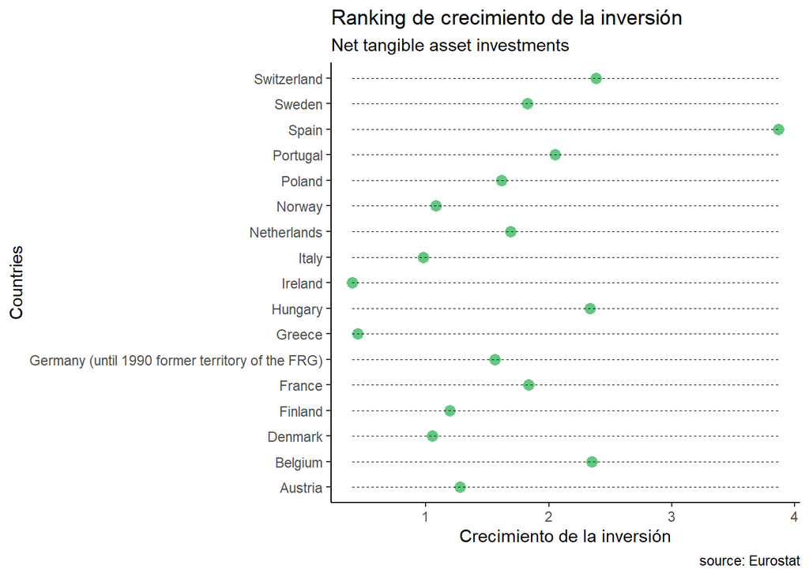

```r
#Crecimiento de InversiÃ³n. EspaÃ±a primera en incremento de la inversiÃ³n.
sp_inv_act15 = construction %>%
  filter(TIME == 2015) %>%
  filter(NACE_R2 == "Construction" ) %>%
  filter(INDIC_SB == "Net investment in tangible goods - million euro") %>%
  group_by(GEO)%>%
  arrange(desc(Value))
sp_inv_act18 = construction %>%
  filter(TIME == 2018) %>%
  filter(NACE_R2 == "Construction" ) %>%
  filter(INDIC_SB == "Net investment in tangible goods - million euro") %>%
  group_by(GEO)%>%
  arrange(desc(Value))

comparacion_anual_invSpain = inner_join(sp_inv_act18, sp_inv_act15, by= "GEO", copy = FALSE)
comparacion_anual_invSpain = comparacion_anual_invSpain[, c(2,5,10)]
colnames(comparacion_anual_invSpain) <- c("GEO", "Y18", "Y15")

comparacion_anual_invSpain = comparacion_anual_invSpain %>%
  mutate(Y18/Y15)%>%
  arrange(desc(Y18/Y15))

# Plot
ggplot(comparacion_anual_invSpain, aes(x=comparacion_anual_invSpain$GEO, y=comparacion_anual_invSpain$`Y18/Y15`)) +
  geom_point(col="#61c87f", size=3) +   # Draw points
  geom_segment(aes(x=comparacion_anual_invSpain$GEO,
                   xend=comparacion_anual_invSpain$GEO,
                   y=min(comparacion_anual_invSpain$`Y18/Y15`),
                   yend=max(comparacion_anual_invSpain$`Y18/Y15`)),
               linetype="dashed",
               size=0.1,
               ) +   # Draw dashed lines
  labs(title="Ranking de crecimiento de la inversión",
       subtitle="Net tangible asset investments",
       caption="source: Eurostat",
       y="Crecimiento de la inversión",
       x="Countries") +
  coord_flip()
```

Nuestro país es el que presenta un mayor incremento en la inversión neta (tanto extranjera como doméstica), lo que explica la competitividad de España a nivel Europeo en el sector de la construcción. Otra manera de visualizar el crecimiento consiste en observar la diferencia absoluta entre 2015 y 2018:

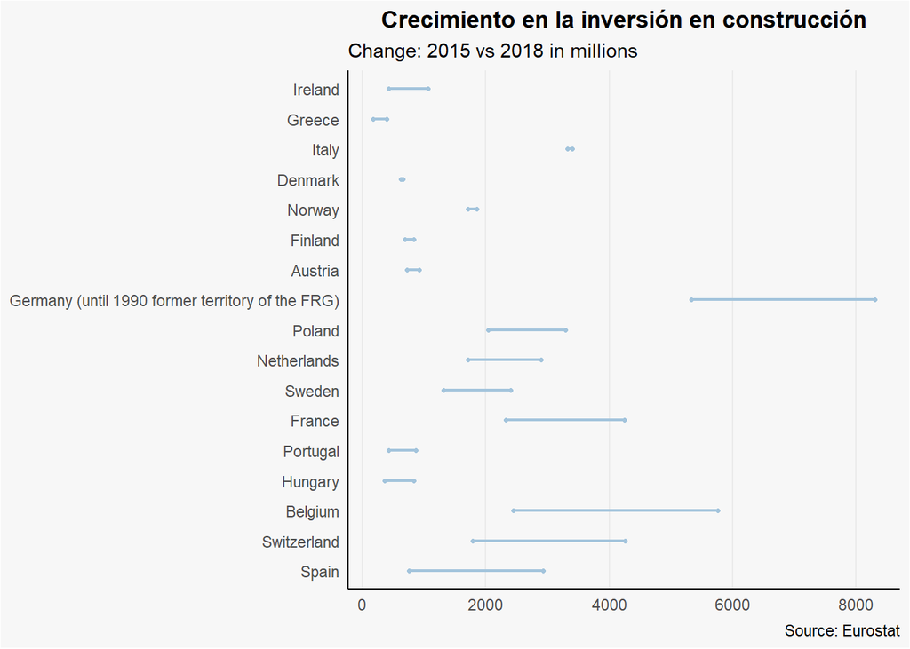

```r
library(ggplot2)
library(ggalt)
theme_set(theme_classic())

comparacion_anual_invSpain$GEO <- factor(comparacion_anual_invSpain$GEO, levels=as.character(comparacion_anual_invSpain$GEO))  # for right ordering of the dumbells

# Hacemos factor el campo GEO
gg <- ggplot(comparacion_anual_invSpain, aes(x=comparacion_anual_invSpain$Y15, xend=comparacion_anual_invSpain$Y18, y=comparacion_anual_invSpain$GEO, group=comparacion_anual_invSpain$GEO)) +
        geom_dumbbell(color="#a3c4dc",
                      size=0.75,
                      point.colour.l="#0e668b") +
        scale_x_continuous() +
        labs(x=NULL,
             y=NULL,
             title="Crecimiento en la inversión en construcción",
             subtitle="Change: 2015 vs 2018 in millions",
             caption="Source: Eurostat") +
        theme(plot.title = element_text(hjust=0.5, face="bold"),
              plot.background=element_rect(fill="#f7f7f7"),
              panel.background=element_rect(fill="#f7f7f7"),
              panel.grid.minor=element_blank(),
              panel.grid.major.y=element_blank(),
              panel.grid.major.x=element_line(),
              axis.ticks=element_blank(),
              legend.position="top",
              panel.border=element_blank())
plot(gg)
```

## Crecimiento de la productividad

Finalmente, estudiamos el crecimiento de la productividad entre 2015 a 2018:

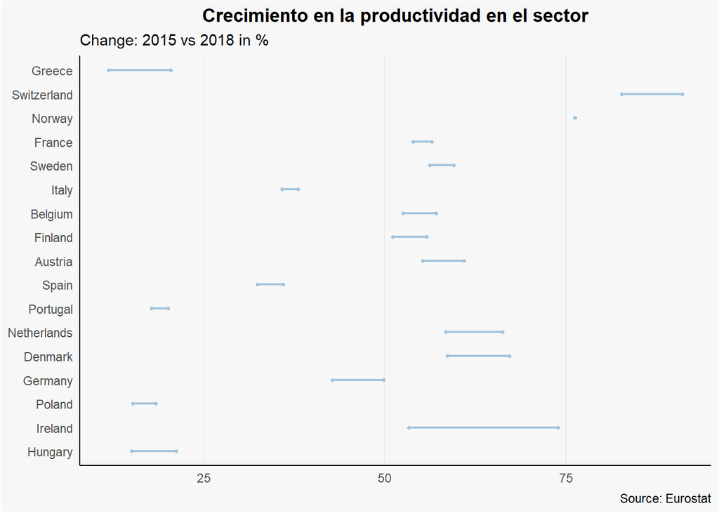

```r
sp_prodPais_pais15 = construction2 %>%
  filter(TIME == 2015) %>%
  filter(NACE_R2 == "Construction" ) %>%
  filter(INDIC_SB == "Apparent labour productivity (Gross value added per person employed) - thousand euro") %>%
  group_by(GEO)%>%
  arrange(desc(Value))

comparacion_anual_prod = inner_join(sp_prodPais_pais18, sp_prodPais_pais15, by= "GEO", copy = FALSE)
comparacion_anual_prod = comparacion_anual_prod[, c(2,5,10)]

colnames(comparacion_anual_prod) <- c("GEO", "Y18", "Y15")

comparacion_anual_prod = comparacion_anual_prod %>%
  mutate(Y18/Y15)%>%
  arrange(desc(Y18/Y15))

# Plot
library(ggplot2)
library(ggalt)
theme_set(theme_classic())

comparacion_anual_prod$GEO <- factor(comparacion_anual_prod$GEO, levels=as.character(comparacion_anual_prod$GEO))  # for right ordering of the dumbells

# Hacemos factor el campo GEO
gg <- ggplot(comparacion_anual_prod, aes(x=comparacion_anual_prod$Y15, xend=comparacion_anual_prod$Y18, y=comparacion_anual_prod$GEO, group=comparacion_anual_prod$GEO)) +
        geom_dumbbell(color="#a3c4dc",
                      size=0.75,
                      point.colour.l="#0e668b") +
        scale_x_continuous() +
        labs(x=NULL,
             y=NULL,
             title="Crecimiento en la productividad en el sector",
             subtitle="Change: 2015 vs 2018 in %",
             caption="Source: Eurostat") +
        theme(plot.title = element_text(hjust=0.5, face="bold"),
              plot.background=element_rect(fill="#f7f7f7"),
              panel.background=element_rect(fill="#f7f7f7"),
              panel.grid.minor=element_blank(),
              panel.grid.major.y=element_blank(),
              panel.grid.major.x=element_line(),
              axis.ticks=element_blank(),
              legend.position="top",
              panel.border=element_blank())
plot(gg)
```

# Rentabilidad media por sub-sector: la cadena de valor de la construcción

Para empezar el análisis interno, se estudian los diferentes sub-sectores de la construcción y sus rentabilidades medias. De esta manera, se podrá priorizar iniciativas para incrementar el impacto del sector en la economía:

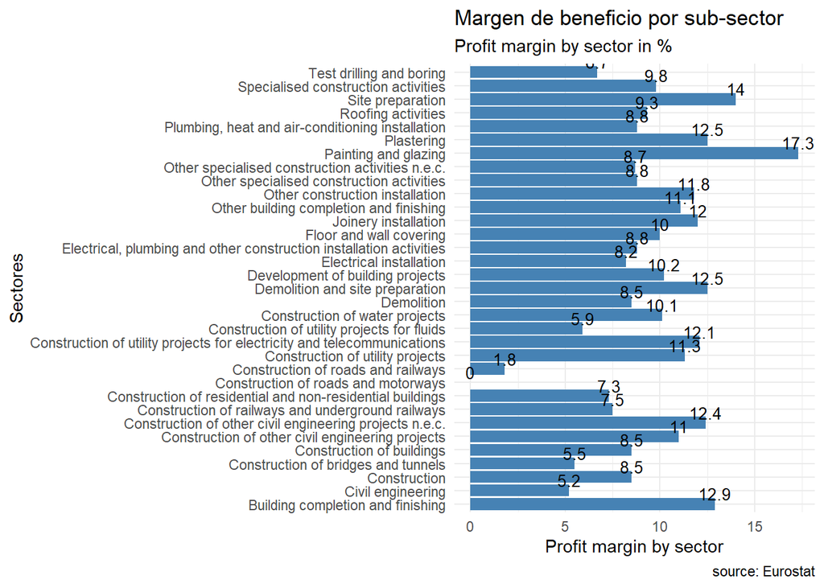

```r
sp_revenue_act = construction %>%
  filter(GEO == "Spain") %>%
  filter(TIME == 2018) %>%
  filter(INDIC_SB == "Turnover or gross premiums written - million euro") %>%
  group_by(NACE_R2)%>%
  arrange(desc(Value))
sp_profitability_act = construction %>%
  filter(GEO == "Spain") %>%
  filter(TIME == 2018) %>%
  filter(INDIC_SB == "Gross operating surplus/turnover (gross operating rate) - percentage") %>%
  group_by(NACE_R2)%>%
  arrange(desc(Value))
profit_pools_spain = inner_join(sp_revenue_act, sp_profitability_act, by= "NACE_R2", copy = FALSE)
profit_pools_spain = profit_pools_spain[, c(3,5,10)]
colnames(comparacion_anual_invSpain) <- c("Sub-sector", "Revenues", "Profitability")

profit_pools_spain = unique(profit_pools_spain)

ggplot(data=profit_pools_spain, aes(x=profit_pools_spain$NACE_R2, y=profit_pools_spain$Value.y)) +
  geom_bar(stat="identity", fill="steelblue")+
  geom_text(aes(label=profit_pools_spain$Value.y), vjust=-0.3, size=3.5)+
  theme_minimal()+
  coord_flip() + labs(title="Margen de beneficio por sub-sector",
       subtitle="Profit margin by sector in %",
       caption="source: Eurostat",
       y="Profit margin by sector",
       x="Sectores")
```

## Priorización de sub-sectores

De la misma manera, se debe de priorizar los subsectores en función de su tamaño respecto a los demás. A mayor tamaño del sector en ingresos y margen de beneficio, mayor impacto directo en la economía:

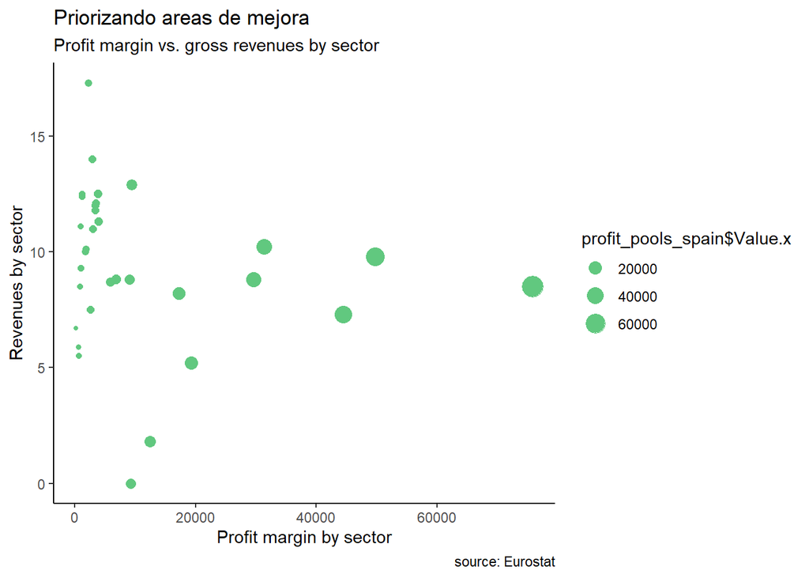

```r
#Transformamos la tabla para eliminar los outliers
profit_pools_spain = unique(profit_pools_spain)
profit_pools_spain = profit_pools_spain %>%
  filter(Value.x < 100000)

#Hacemos un scatter-plot
ggplot(profit_pools_spain, aes(x=profit_pools_spain$Value.x, y=profit_pools_spain$Value.y)) + geom_point(aes(size=profit_pools_spain$Value.x), col="#61c87f") + labs(title="Priorizando areas de mejora",
       subtitle="Profit margin vs. gross revenues by sector",
       caption="source: Eurostat",
       y="Revenues by sector",
       x="Profit margin by sector")
```

Así, los subsectores que se encuentran en el cuadrante superior derecho son los que deberían ser priorizados por su potencial impacto en la economía.

Finalmente, debemos de tener en cuenta la productividad. Aquellos sectores que pueden generar un gran impacto en la economía pero que se encuentrar en niveles de productividad bastante inferiores a los europeos. Así, se procede a crear un nuevo scatterplot teniendo en cuenta ambas dimensiones:

```r
profit_pools_spain = unique(profit_pools_spain)
productivity_vs = construction %>%
  filter(GEO == "Spain") %>%
  filter(TIME == 2018) %>%
  filter(INDIC_SB == "Apparent labour productivity (Gross value added per person employed) - thousand euro") %>%
  group_by(NACE_R2)%>%
  arrange(desc(Value))

prioritization = inner_join(profit_pools_spain, productivity_vs, by= "NACE_R2", copy = FALSE)
prioritization = prioritization[, c(1,2,3,7)]
colnames(prioritization) <- c("Sectores", "Revenues", "Profit Margin", "Productivity")
prioritization
```

```
## # A tibble: 34 x 4
## # Groups:   Sectores [32]
##    Sectores                                Revenues `Profit Margin` Productivity
##    <chr>                                      <dbl>           <dbl>        <dbl>
##  1 Construction of buildings                 75845.             8.5         36.1
##  2 Specialised construction activities       49734.             9.8         33
##  3 Construction of residential and non-re~   44420.             7.3         29.9
##  4 Construction of residential and non-re~   44420.             7.3         29.9
##  5 Development of building projects          31425.            10.2         68
##  6 Development of building projects          31425.            10.2         68
##  7 Electrical, plumbing and other constru~   29631.             8.8         35.1
##  8 Civil engineering                         19321.             5.2         52.2
##  9 Electrical installation                   17262.             8.2         35.7
## 10 Construction of roads and railways        12434.             1.8         50.8
## # ... with 24 more rows
```

Finalmente, volvemos a comparar los ingresos por inductria vs. la productivida. Esta vez, se toma el ancho de los puntos como el margen de beneficios. Así, la siguiente visualización muestra una combinación de los tres elementos que se emplearán para priorizar sub-sectores:

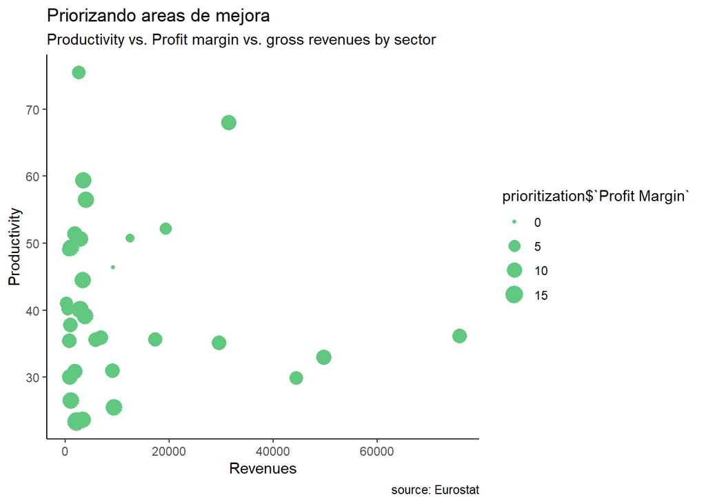

```r
ggplot(prioritization, aes(x=prioritization$Revenues, y=prioritization$Productivity)) + geom_point(aes(size=prioritization$`Profit Margin`),col="#61c87f") + labs(title="Priorizando areas de mejora",
       subtitle="Productivity vs. Profit margin vs. gross revenues by sector",
       caption="source: Eurostat",
       y="Productivity",
       x="Revenues")
```

Para esta última visualización, los sectores a priorizar se ubican en el *cuadrante inferior derecha*, que *maximizan impacto sobre el PIB* y *espacio para la mejora* a nivel productividad.

Teniendo en cuenta las tres dimensiones, se pueden *priorizar una serie de sub-sectores* para continuar fortaleciendo la posición competitiva de la industria:

1. Construction of buildings
2. Specialized construction activities
3. Construction of residential and non-residential buildings
4. Electrical and plumbing
5. Electrical installation
6. Completion & finishing